# Marginal modelling of clustered survival data

# Goodness of fit

The observed score process is given by
$$\begin{align}
U(t,\hat \beta) & = \sum_k \sum_i \int_0^t (Z_{ki} - \hat E_g ) d
\hat M_{ki}^g
\end{align}$$
where $g$ is strata $g(k,i)$. The observed score has the iid decomposition
$$\begin{align}
\hat U(t) = \sum_k \sum_i \int_0^t (Z_{ki} - E_g) dM_{ki}^g -
I(t) \sum_k \beta_k
\end{align}$$
where $\beta_k$ is the iid decomposition of the score process for the true $\beta$
$$\begin{align}
\beta_k & = I(\tau)^{-1} \sum_i \int_0^\tau (Z_{ki} - E_g )
d M_{ki}^g
\end{align}$$
and $I(t)$ is the derivative of the total score, $\hat U(t,\beta))$, with respect to $\beta$ evaluated at time $t$.

This observed score can be resampled given it is on iid form in terms of clusters.

Now using the cumulative score process for checking proportional hazards

```r
gout <- gof(out)
gout
```

```
#> Cumulative score process test for Proportionality:
#>   Sup|U(t)|  pval
#> x  30.24353 0.401
```

The p-value reflects whether the observed score process is consistent with the model.

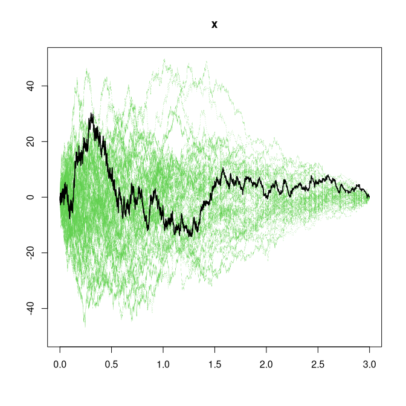

```r
  plot(gout)
```

## Computational aspects

The score processes can be resampled as in Lin, Wei, Ying (1993) using the martingale structure, such that the observed score process is resampled by
$$\begin{align}
\sum_k \sum_i \int_0^t g_{ki} (Z_{ki} - E_g) dN_{ki} -
I(t) I^{-1}(\tau) g_{ki} \int_0^{\tau} (Z_{ki} - E_g) dN_{ki} .
\end{align}$$
where $g_{ki}$ are i.i.d. standard normals.

Based on the zero mean processes we more generally with clusters can resample the score process. For resampling of score process we need
$$\begin{align}
U(t,\beta) & = \sum_k \sum_i g_k \int_0^t (Z_{ki} - E_g ) dM_{ki}^g
\end{align}$$
where $g$ is strata. We write $g_k$ as $g_{ki}$ and thus repeating $g_k$ within each cluster.

Computations are done using that
$$\begin{align*}
\int_0^t (Z_{ki} - E_{g}) dM_{ki}^g & = \int_0^t (Z_{ki} - E_{g})
dN_{ki}^g - \int_0^{t} (Z_{ki} - E_{g}) Y_{ki}(u) d\Lambda^g(u)
\end{align*}$$
therefore and summing the compensator part with the $g_{ki}$ multipliers then gives for each strata $g$
$$\begin{align*}
& \int_0^t \frac{S_{1g}^w(u)}{S_{0g}(u)} dN_{g.}(v) - \int_0^t
E_{g}(u) \frac{S_{0g}^w(u)}{S_{0g}(u)} dN_{g.}(v)
\end{align*}$$
with
$$\begin{align*}
S_{jg}^w(t) & = \sum_{ki \in g} \exp(Z_{ki} \beta) Z_{ki}^j
Y_{ki}(t) g_{ki} \\
S_{jg}(t) & = \sum_{ki \in g} \exp(Z_{ki} \beta) Z_{ki}^j
Y_{ki}(t).
\end{align*}$$

# Cluster stratified Cox models

For clustered data it is possible to estimate the regression coefficient within clusters by using Cox’s partial likelihood stratified on clusters.

Note, here that the data is generated with a different subject specific structure, so we will not recover $\beta = 0.3$ and the model will not be a proportional Cox model; we would therefore also expect to reject “proportionality” with the goodness-of-fit test.

The model can be thought of as
$$\lambda_{g(k,i)} (t) \exp( X_{ki}^T \beta)$$
where $\lambda_g(t)$ is some cluster specific baseline.

The regression coefficient $\beta$ can be estimated by using the partial likelihood for clusters.

```r
 out <- phreg(Surv(time,status)~x+strata(cluster),data=data)
 summary(out)
```

```
#>
#>     n events
#>  5000   4854
#> coefficients:
#>   Estimate     S.E.  dU^-1/2 P-value
#> x 0.406307 0.032925 0.039226       0
#>
#> exp(coefficients):
#>   Estimate   2.5%  97.5%
#> x   1.5013 1.4074 1.6013
```